# Modelos Arma

## Série 2

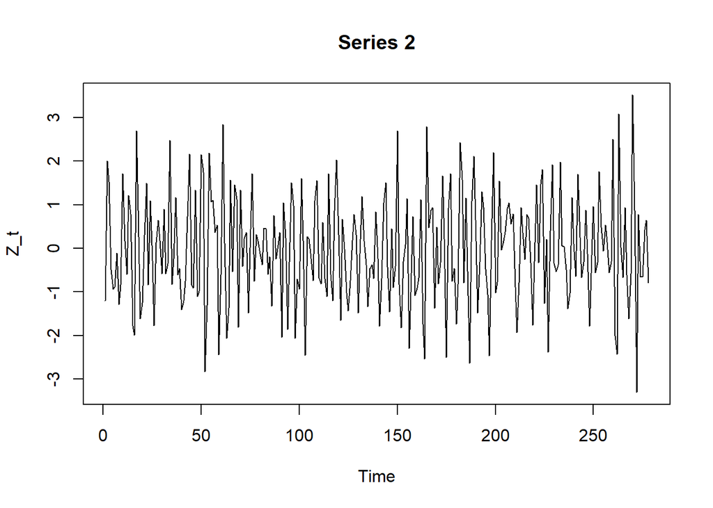

```r
plot(X[[2]], main = "Series 2", ylab = "Z_t")
```

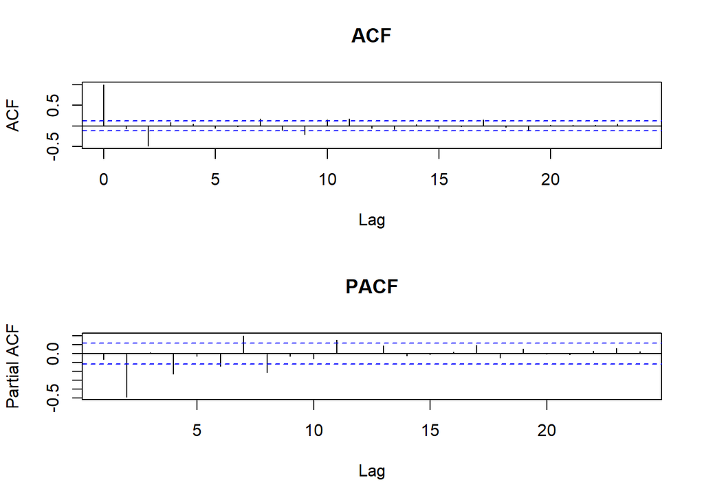

```r
plot_acf_pacf(X[[2]])
```

Agora, visualizamos um situação inversa, o lag 2 é significativo na ACF e nos demais não, e na PACF o decrescimento é gradual, o que nos faz pensar se tratar de um modelo MA(2). No entanto, como na PACF o lag 2 também é significativo, iremos comparar com o modelo ARMA(2, 2).

```r
model2 <- arma(X[[2]], order = c(0, 2))
summary(model2)
```

```
##
## Call:
## arma(x = X[[2]], order = c(0, 2))
##
## Model:
## ARMA(0,2)
##
## Residuals:
##      Min       1Q   Median       3Q      Max
## -2.49044 -0.77251  0.01282  0.77130  2.82319
##
## Coefficient(s):
##            Estimate  Std. Error  t value Pr(>|t|)
## ma1         0.11057     0.04029    2.745  0.00606 **
## ma2        -0.70037     0.03931  -17.818  < 2e-16 ***
## intercept  -0.03815     0.02510   -1.520  0.12855
## ---
## Signif. codes:  0 '***' 0.001 '**' 0.01 '*' 0.05 '.' 0.1 ' ' 1
##
## Fit:
## sigma^2 estimated as 1.025,  Conditional Sum-of-Squares = 281.95,  AIC = 801.86
```

O modelo se encaixou bem, vamos comparar a previsão e o real, e em sequência, o plot de resíduos.

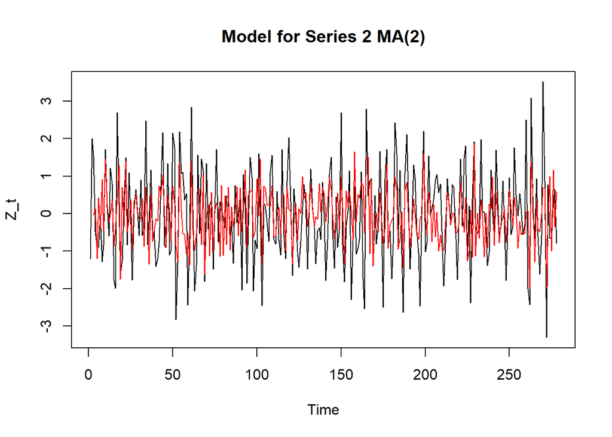

```r
plot(X[[2]], main = "Model for Series 2 MA(2)", ylab = "Z_t")
lines(model2$fitted.values, col = "red")
```

Realizando o mesmo processo com o modelo ARMA(2, 2).

```r
model2 <- arma(X[[2]], order = c(2, 2))
summary(model2)
```

```
##
## Call:
## arma(x = X[[2]], order = c(2, 2))
##
## Model:
## ARMA(2,2)
##
## Residuals:
##      Min       1Q   Median       3Q      Max
## -2.54256 -0.76754  0.01269  0.73690  2.67023
##
## Coefficient(s):
##            Estimate  Std. Error  t value Pr(>|t|)
## ar1        -0.20365     0.08558   -2.380  0.01733 *
## ar2        -0.12123     0.07719   -1.571  0.11627
## ma1         0.21277     0.06716    3.168  0.00153 **
## ma2        -0.61986     0.06320   -9.808  < 2e-16 ***
## intercept  -0.04935     0.03605   -1.369  0.17106
## ---
## Signif. codes:  0 '***' 0.001 '**' 0.01 '*' 0.05 '.' 0.1 ' ' 1
##
## Fit:
## sigma^2 estimated as 1.003,  Conditional Sum-of-Squares = 275.78,  AIC = 799.72
```

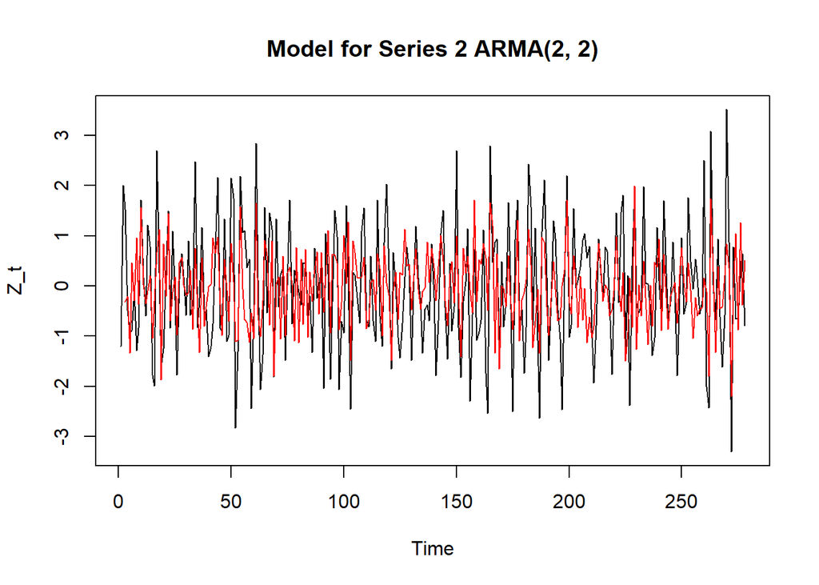

```r
plot(X[[2]], main = "Model for Series 2 ARMA(2, 2)", ylab = "Z_t")
lines(model2$fitted.values, col = "red")
```

Vemos que apesar de extramemente parecidos, o modelo ARMA(2, 2) teve o AIC um pouquinho menor. Vamos visualizar o resíduo obtido com ele:

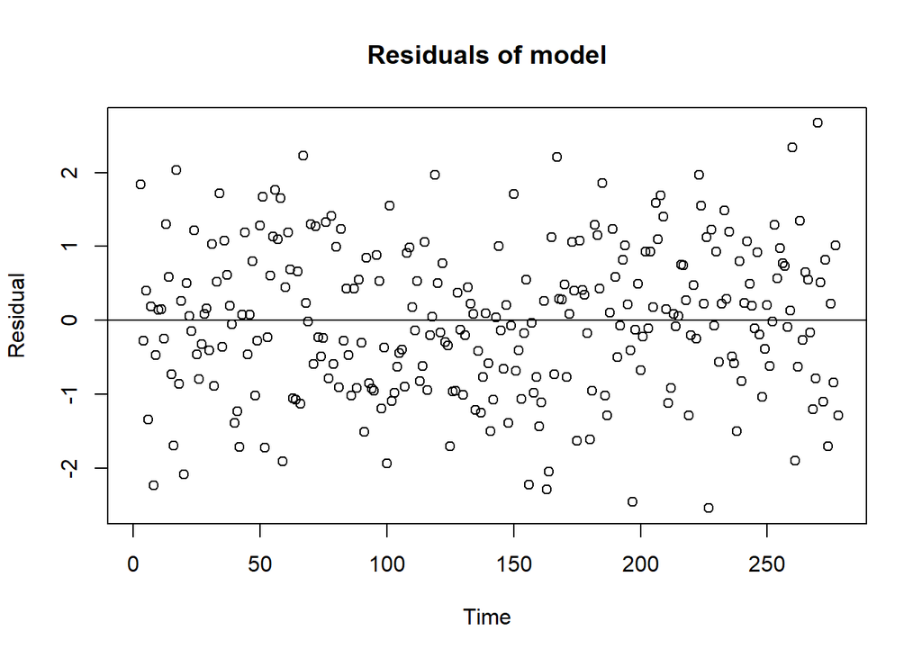

```r
plot_res(model2$residuals)
```

O modelo aparentemente se adequa bem a sazonalidade da série real, no entanto, não conseguimos capturar os picos extremos como ocorrem na série real, e os resíduos também se distribuem uniformemente ao longo da série.

## Série 3

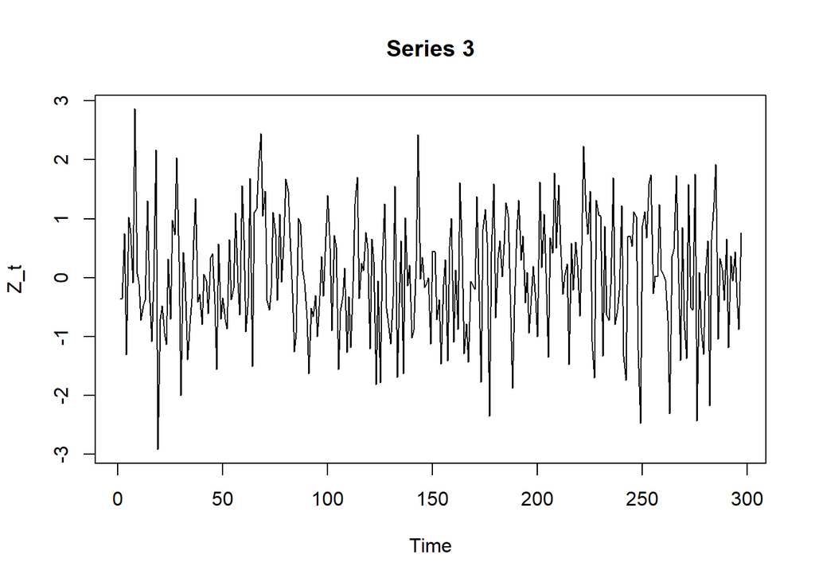

```r
plot(X[[3]], main = "Series 3", ylab = "Z_t")
```

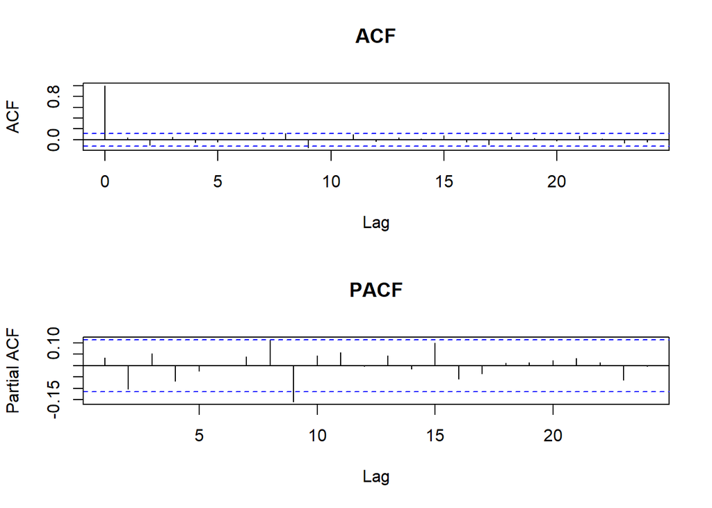

```r
plot_acf_pacf(X[[3]])
```

Nesse modelo existe um comportamento diferente dos demais, tanto a ACF quanto a PACF são praticamente nulas para todos os valores, menos para a ACF de 0, o que indica que as amostras não possuem covariância, se comportando como um ruído branco. Vamos verificar a média e a variância da série.

```r
data.frame(mean = mean(X[[3]]), variance = var(X[[3]])*296/297)
```

```
##         mean variance
## 1 0.03941307 1.021629
```

Vemos que o modelo se comporta como um ruído branco, isto é, $a_t$ com $E(a_t)=0$ e $Var(a_t) = 1$. Se nós gerarmos $297$ amostras de $a_t$ e visualizarmos tanto o modelo e predição, quanto o residual, teremos:

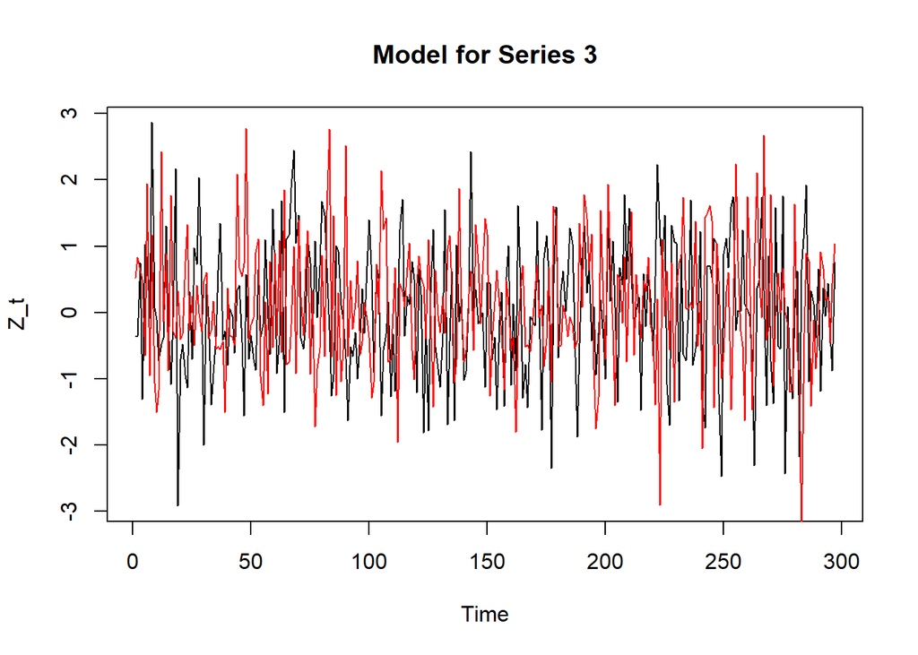

```r
model3 <- rnorm(297)
plot(X[[3]], main = "Model for Series 3", ylab = "Z_t")
lines(model3, col = "red")
```

```r
model3$residual <- X[[3]] - model3
```

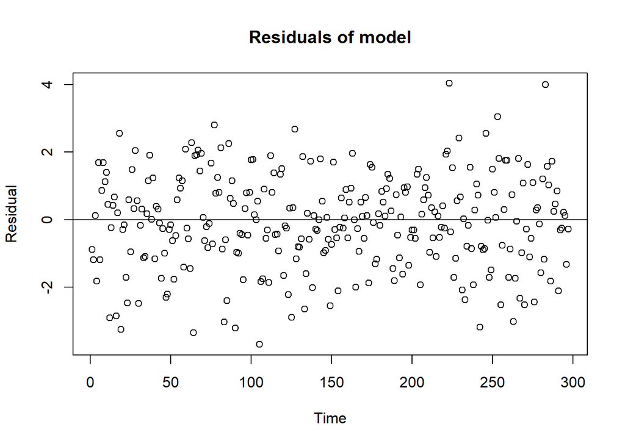

```r
plot_res(model3$residual)
```

## Série 4

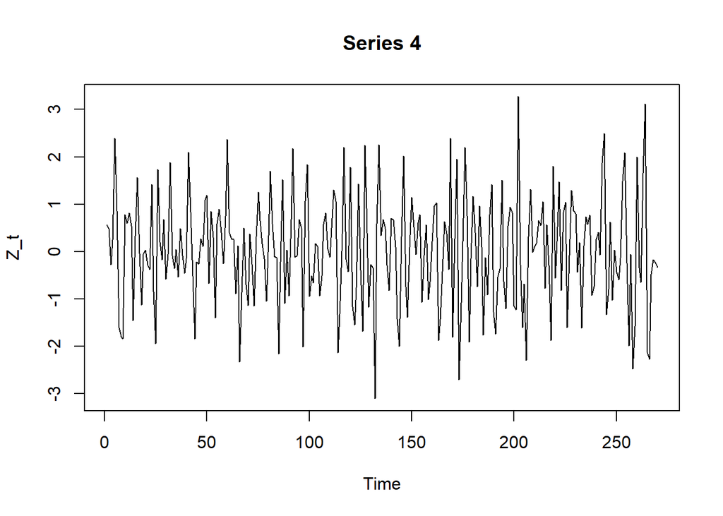

```r
plot(X[[4]], main = "Series 4", ylab = "Z_t")
```

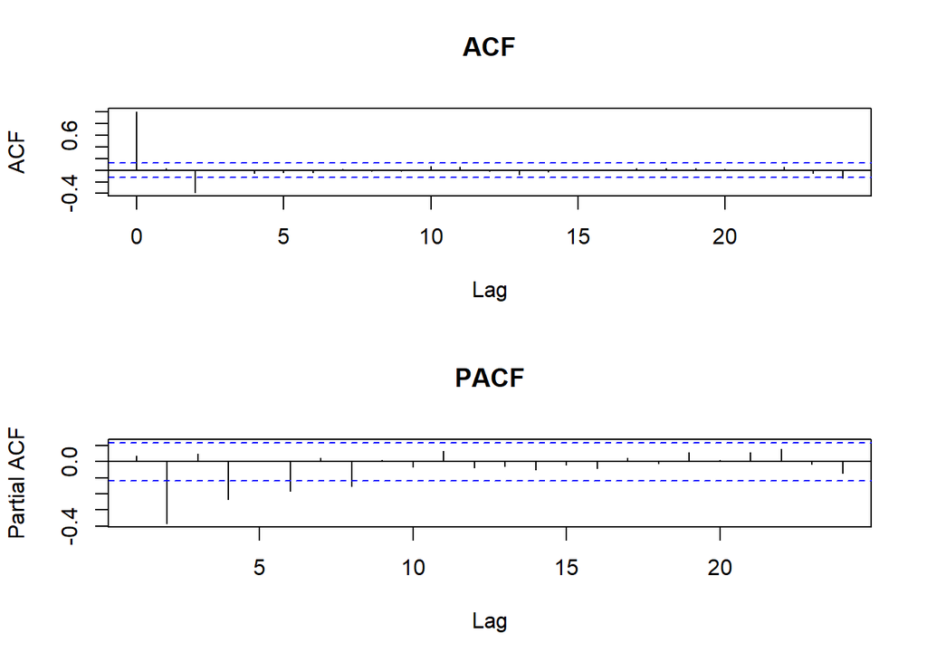

```r
plot_acf_pacf(X[[4]])
```

A série apresenta uma função de ACF que cai drasticamente após o lag 2, enquanto a PACF cai mais gradualmente de forma exponencial, o que dá a noção de se tratar de um modelo MA(2). Utilizando dessa observação, fitamos:

```r
model4 <- arma(X[[4]], order = c(0, 2))
summary(model4)
```

```
##
## Call:
## arma(x = X[[4]], order = c(0, 2))
##
## Model:
## ARMA(0,2)
##
## Residuals:
##      Min       1Q   Median       3Q      Max
## -3.20748 -0.68404  0.06891  0.64994  2.84235
##
## Coefficient(s):
##            Estimate  Std. Error  t value Pr(>|t|)
## ma1         0.09013     0.05112    1.763   0.0779 .
## ma2        -0.61589     0.05318  -11.581   <2e-16 ***
## intercept   0.01590     0.02884    0.551   0.5813
## ---
## Signif. codes:  0 '***' 0.001 '**' 0.01 '*' 0.05 '.' 0.1 ' ' 1
##
## Fit:
## sigma^2 estimated as 0.9865,  Conditional Sum-of-Squares = 263.41,  AIC = 768.57
```

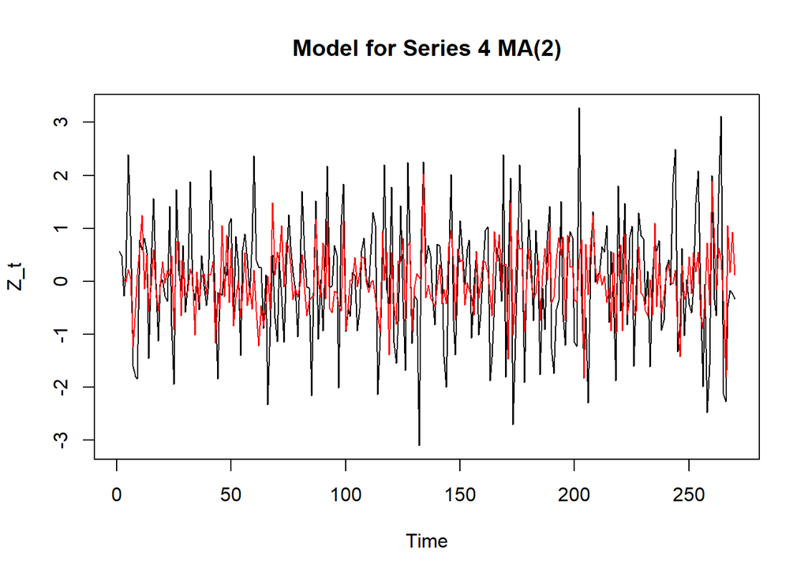

```r
plot(X[[4]], main = "Model for Series 4 MA(2)", ylab = "Z_t")
lines(model4$fitted.values, col = "red")
```

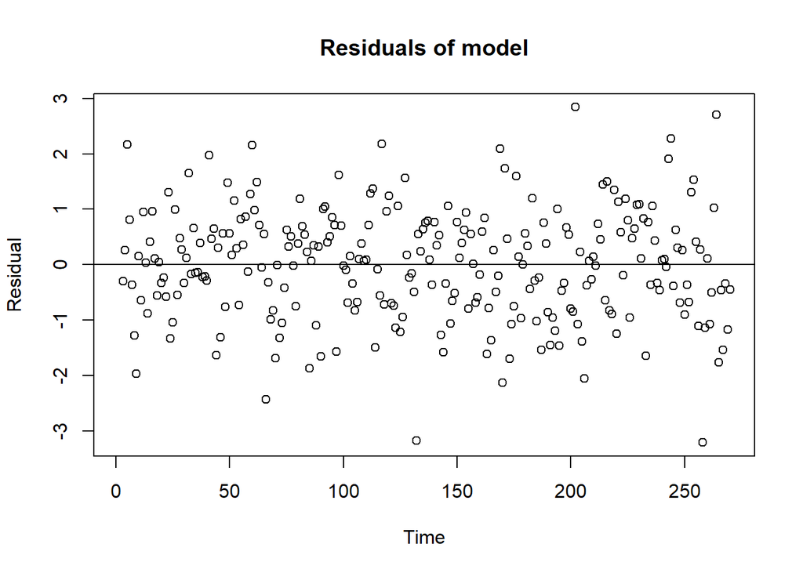

```r
plot_res(model4$residuals)
```

O modelo se encaixou bem aos dados, incluindo apresentando uma distribuição uniforme dos ruídos.

## Série 5

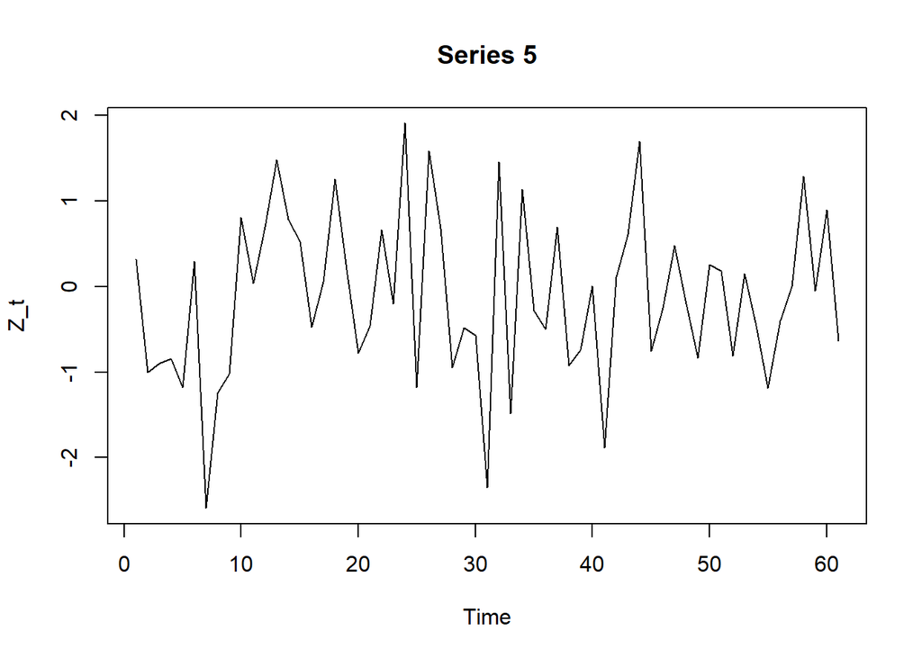

```r
plot(X[[5]], main = "Series 5", ylab = "Z_t")
```

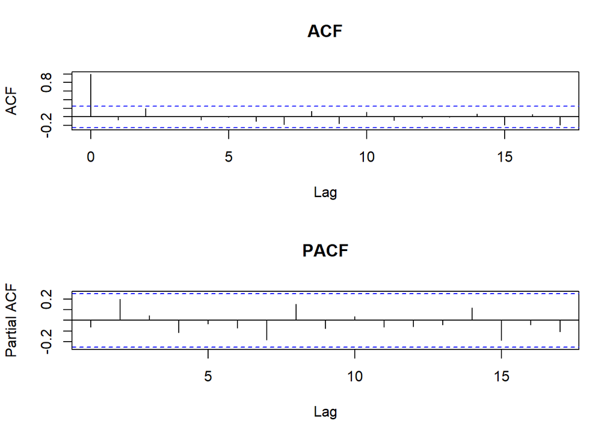

```r
plot_acf_pacf(X[[5]])
```

Vemos que tanto a ACF quanto a PACF são extremamente baixas para valores diferentes de 0, no entanto, nessa série possuímos bem menos amostras que as demais, possuindo apenas 61 amostras. Por esse motivo, iremos considerar que a importância do segundo lag na PACF e avaliar dois modelos distintos, AR(2) e ARMA(2, 2). Considerando primeiro o modelo AR(2).

```r
model5 <- arma(X[[5]], order = c(2, 0))
summary(model5)
```

```
##
## Call:
## arma(x = X[[5]], order = c(2, 0))
##
## Model:
## ARMA(2,0)
##
## Residuals:
##      Min       1Q   Median       3Q      Max
## -2.24498 -0.70396  0.01893  0.71961  1.85873
##
## Coefficient(s):
##            Estimate  Std. Error  t value Pr(>|t|)
## ar1        -0.04726     0.12481   -0.379    0.705
## ar2         0.20225     0.12576    1.608    0.108
## intercept  -0.09259     0.12355   -0.749    0.454
##
## Fit:
## sigma^2 estimated as 0.9154,  Conditional Sum-of-Squares = 53.09,  AIC = 173.72
```

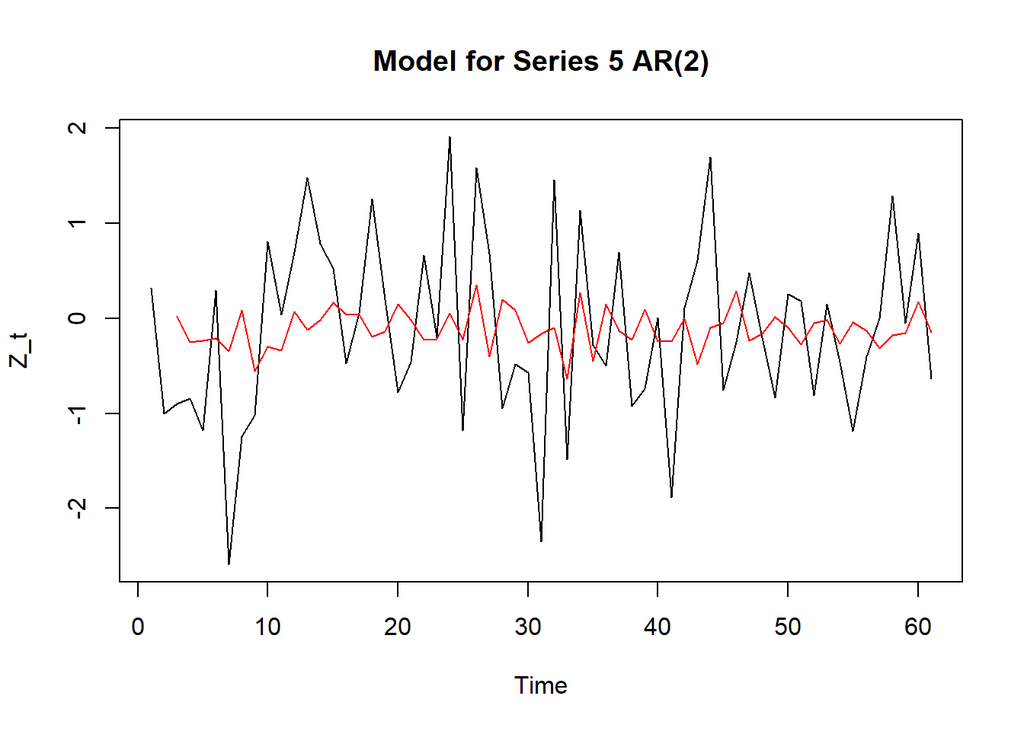

```r
plot(X[[5]], main = "Model for Series 5 AR(2)", ylab = "Z_t")
lines(model5$fitted.values, col = "red")
```

E agora o modelo ARMA(2, 2).

```r
model5 <- arma(X[[5]], order = c(2, 2))
summary(model5)
```

```
##
## Call:
## arma(x = X[[5]], order = c(2, 2))
##
## Model:
## ARMA(2,2)
##
## Residuals:
##      Min       1Q   Median       3Q      Max
## -2.16208 -0.48610 -0.01902  0.57863  2.30147
##
## Coefficient(s):
##            Estimate  Std. Error  t value Pr(>|t|)
## ar1         0.81736     0.17739    4.608 4.07e-06 ***
## ar2        -0.62001     0.10722   -5.783 7.35e-09 ***
## ma1        -0.92912     0.09675   -9.603  < 2e-16 ***
## ma2         0.95619     0.10319    9.266  < 2e-16 ***
## intercept  -0.12685     0.11679   -1.086    0.277
## ---
## Signif. codes:  0 '***' 0.001 '**' 0.01 '*' 0.05 '.' 0.1 ' ' 1
##
## Fit:
## sigma^2 estimated as 0.8179,  Conditional Sum-of-Squares = 47.54,  AIC = 170.85
```

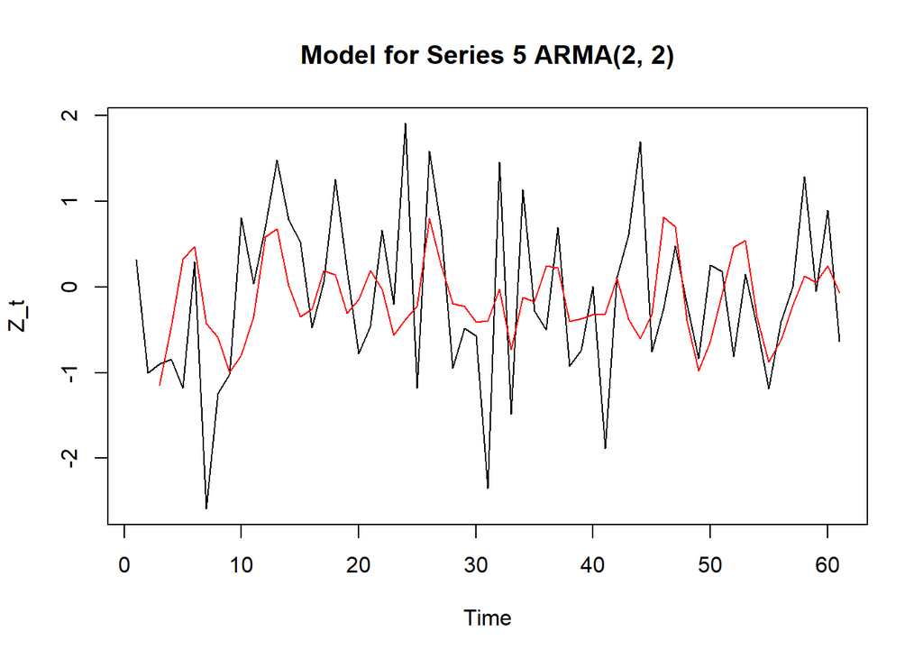

```r
plot(X[[5]], main = "Model for Series 5 ARMA(2, 2)", ylab = "Z_t")
lines(model5$fitted.values, col = "red")
```

Vemos que o modelo ARMA(2, 2) apresentou um AIC menor, de 170, em comparação com o AR(2), além disso, ele também encaixou melhor na curva real dos dados. Vamos visualizar os resíduos:

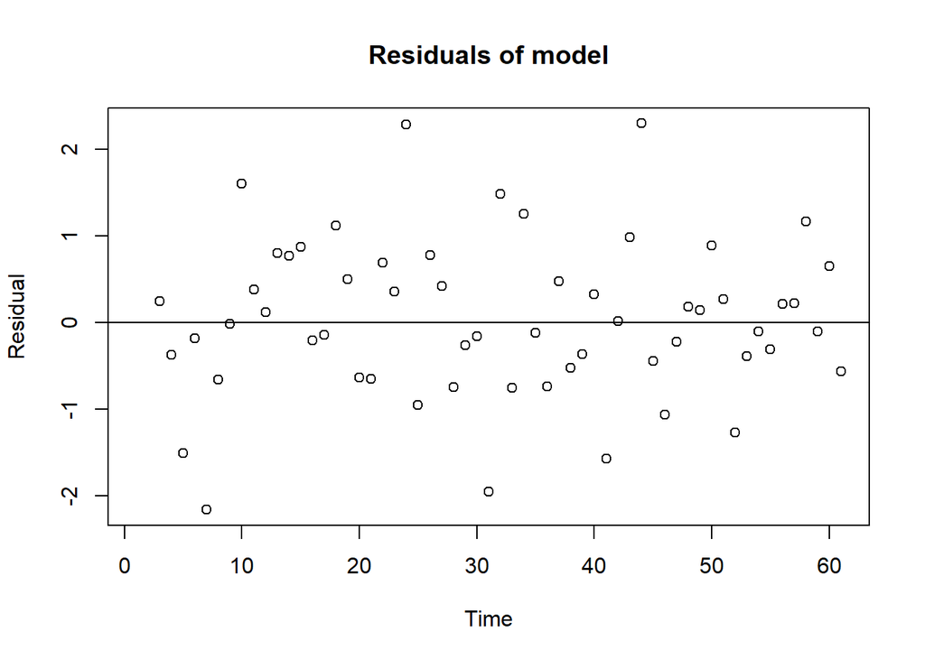

```r
plot_res(model5$residuals)
```

## Série 6

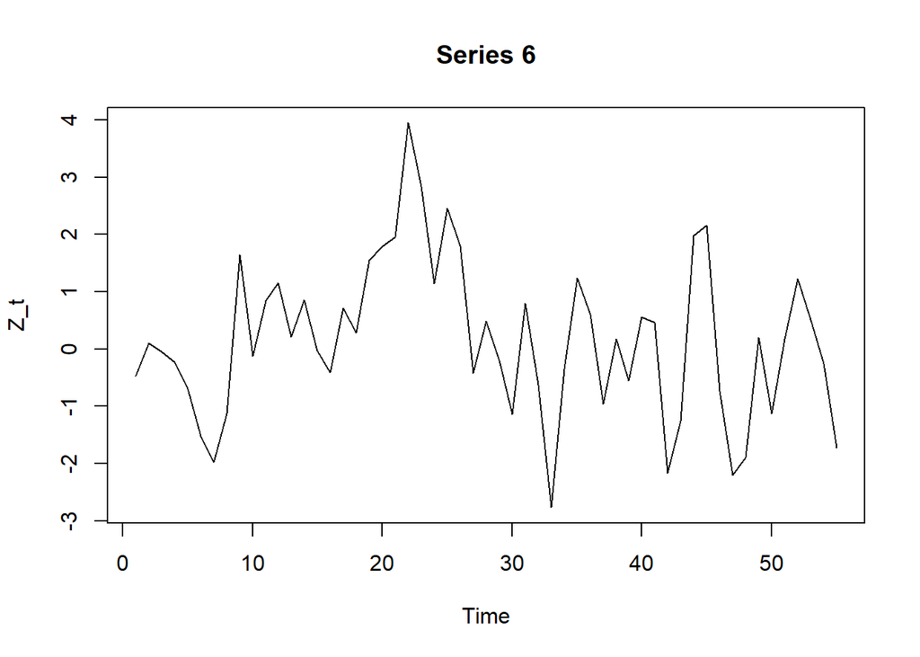

```r
plot(X[[6]], main = "Series 6", ylab = "Z_t")
```

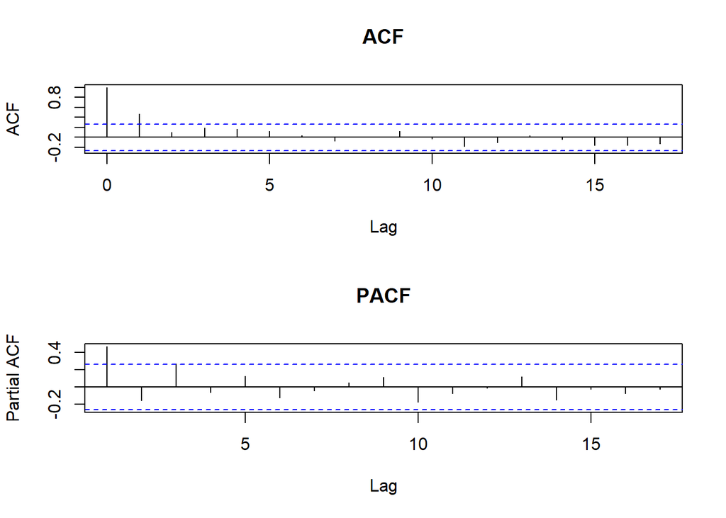

```r
plot_acf_pacf(X[[6]])
```

```r
model6 <- arma(X[[6]], order = c(0, 1))
summary(model6)
```

```
##
## Call:
## arma(x = X[[6]], order = c(0, 1))
##
## Model:
## ARMA(0,1)
##
## Residuals:
##      Min       1Q   Median       3Q      Max
## -1.85487 -0.90462 -0.06636  0.78021  2.74265
##
## Coefficient(s):
##            Estimate  Std. Error  t value Pr(>|t|)
## ma1          0.7129      0.0991    7.194 6.31e-13 ***
## intercept    0.1458      0.2557    0.570    0.569
## ---
## Signif. codes:  0 '***' 0.001 '**' 0.01 '*' 0.05 '.' 0.1 ' ' 1
##
## Fit:
## sigma^2 estimated as 1.29,  Conditional Sum-of-Squares = 68.38,  AIC = 174.1
```

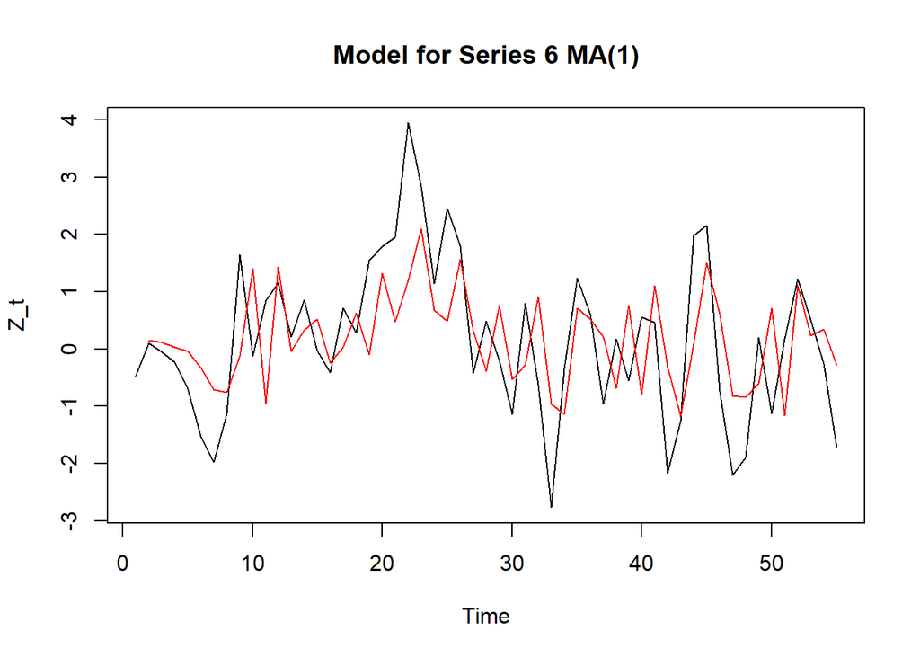

```r
plot(X[[6]], main = "Model for Series 6 MA(1)", ylab = "Z_t")
lines(model6$fitted.values, col = "red")
```

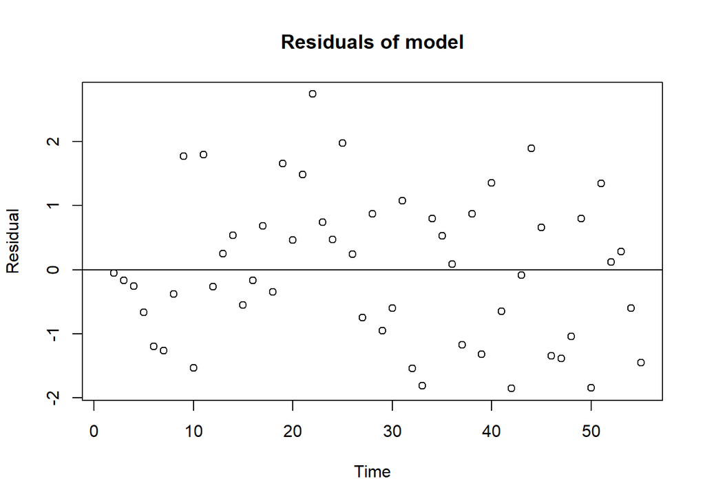

```r
plot_res(model6$residuals)
```

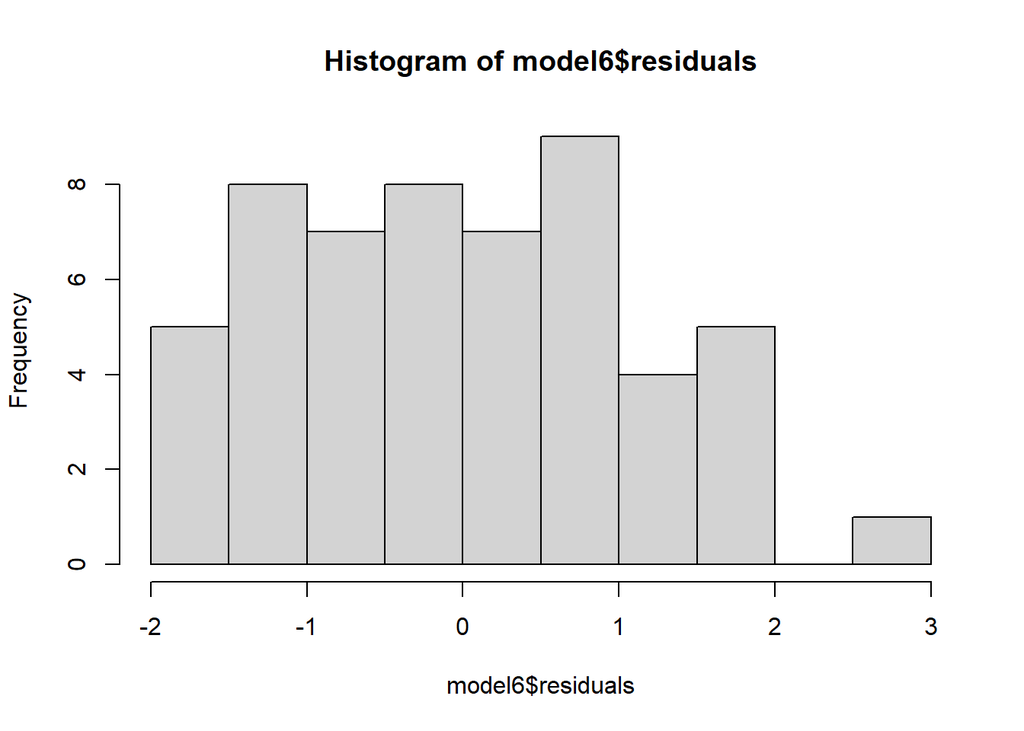

```r
hist(model6$residuals)
```

O modelo não conseguiu capturar bem os picos da série real, mas se encaixou razoavelmente bem.